# Jun Simons - other 2D plot styles

For two dimensional plotting in the previous project, the plot() method was used, which creates a standard 2D plot. Other types of plots can be useful for displaying data, and different methods are used.

The complete list of plot types can be found here: https://matplotlib.org/gallery.html  
**Horizontal Bar**: barh()  
**Vertical Bar**: bar()  
**Scatter Plot**: scatter()  
**Step function**: step()  
**Fill between functions**: fill_between()  
**Boxplot**: boxplot()  
**Pie chart**: pie()

```python
%matplotlib inline
```

```python
import matplotlib
import matplotlib.pyplot as plt
import numpy as np
from pylab import *

from matplotlib import cm
from colorspacious import cspace_converter
from collections import OrderedDict

cmaps = OrderedDict()
```

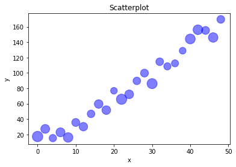

```python
x = np.arange(0.0,50.0,2.0)
y = x**1.3 + np.random.rand(*x.shape) * 30.0
s = np.random.rand(*x.shape) * 800 + 500 # randomizing size
plt.scatter(x,y,s,c="b",alpha=.5,marker='.')
plt.title("Scatterplot")
plt.xlabel('x')
plt.ylabel('y')
plt.show()
```

```python
arr = np.array([0,1,2,3,4,5,6,7])
```

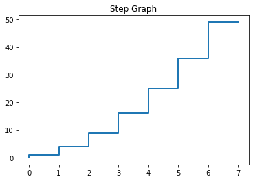

```python
fig,ax = plt.subplots()
ax.step(arr,arr**2,lw=2)
ax.set_title("Step Graph")
```

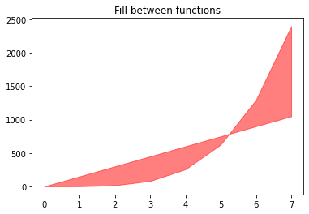

```python
fig,ax = plt.subplots()
ax.fill_between(arr,arr*150,arr**4,color="red",alpha=.5)
ax.set_title("Fill between functions")
```

## Histogram data

Pyplot has a histogram method, hist(), that can be used in a few different ways.

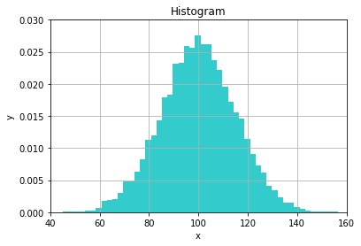

```python
mu,sigma = 100,15
x = mu+sigma*np.random.randn(10000)

n,bins,patches = plt.hist(x,50,density=True,facecolor='c',alpha=.8) #Creating the histogram

plt.title('Histogram')
plt.xlabel('x')
plt.ylabel('y')
plt.xlim(40,160)
plt.ylim(0,.03)
plt.grid(True)
plt.show()
```

# Polar Graphs!

Polar graphs can also be modeled by using the *polar* parameter of fig.add_axes().

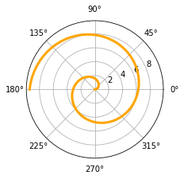

```python
fig=plt.figure()
ax = fig.add_axes([0.0, 0.0, .6, .6], polar=True)
t = np.linspace(0,3*np.pi,100)
ax.plot(t,t,color='orange',lw=3)
```

**We can combine these and make a polar scatterplot:**

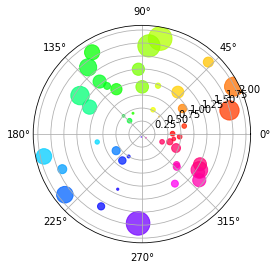

```python
N = 50
r = np.random.rand(N)*2
theta = 2 * np.pi * np.random.rand(N)
area = 200 * r**2 * np.random.rand(N)
colors = theta

ax = plt.subplot(111, polar=True)
c = plt.scatter(theta, r, c=colors, s=area, cmap=plt.cm.hsv)
c.set_alpha(0.75)

plt.show()
```

# Contour and Colormap

These produce some of the most interesting looking charts that can be used to plot functions with two variables.  
Below, the colormaps defined list the default matplot lib colormaps.

```python
cmaps['Perceptually Uniform Sequential'] = [ #lightness increases monotonically
            'viridis', 'plasma', 'inferno', 'magma', 'cividis']

cmaps['Sequential'] = [
            'Greys', 'Purples', 'Blues', 'Greens', 'Oranges', 'Reds',
            'YlOrBr', 'YlOrRd', 'OrRd', 'PuRd', 'RdPu', 'BuPu',
            'GnBu', 'PuBu', 'YlGnBu', 'PuBuGn', 'BuGn', 'YlGn']
cmaps['Sequential (2)'] = [
            'binary', 'gist_yarg', 'gist_gray', 'gray', 'bone', 'pink',
            'spring', 'summer', 'autumn', 'winter', 'cool', 'Wistia',
            'hot', 'afmhot', 'gist_heat', 'copper']
cmaps['Diverging'] = [ #lightness increases and then decreases monotonically, splitting around the center
            'PiYG', 'PRGn', 'BrBG', 'PuOr', 'RdGy', 'RdBu',
            'RdYlBu', 'RdYlGn', 'Spectral', 'coolwarm', 'bwr', 'seismic']
cmaps['Cyclic'] = ['twilight', 'twilight_shifted', 'hsv'] #cycle color, starting and ending at the same value
cmaps['Qualitative'] = ['Pastel1', 'Pastel2', 'Paired', 'Accent', #NOT monotonic (obviously)
                        'Dark2', 'Set1', 'Set2', 'Set3',
                        'tab10', 'tab20', 'tab20b', 'tab20c']
cmaps['Miscellaneous'] = [
            'flag', 'prism', 'ocean', 'gist_earth', 'terrain', 'gist_stern',
            'gnuplot', 'gnuplot2', 'CMRmap', 'cubehelix', 'brg',
            'gist_rainbow', 'rainbow', 'jet', 'nipy_spectral', 'gist_ncar']
```

## Visual representation of colormaps

Below is a loop through all the colormaps listed above, *which were sourced from the Matplotlib website.*

The imshow() method allows you to input RGB or 2D scalar data and render it in the form of a pseudocolor image, and could be made grayscale if desired. In this case we pass a gradient to be graphed, and pass each colormap in the *cmap* parameter so that the colormap is used to map the scalar data held in *gradient* to the colors.

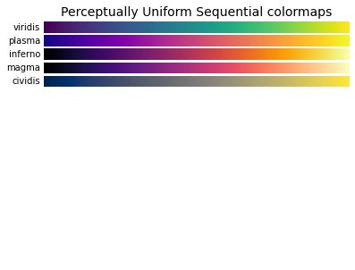

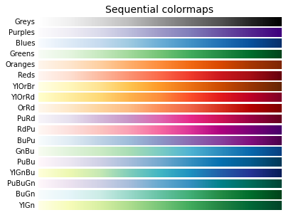

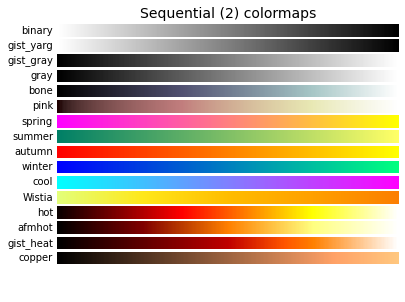

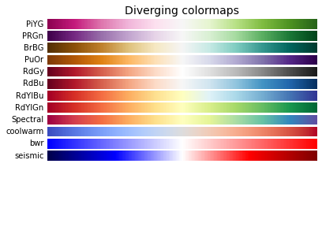

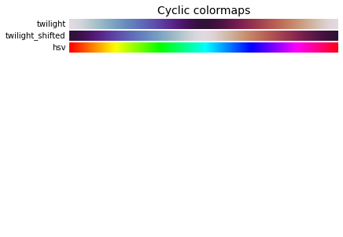

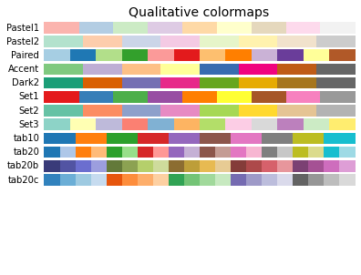

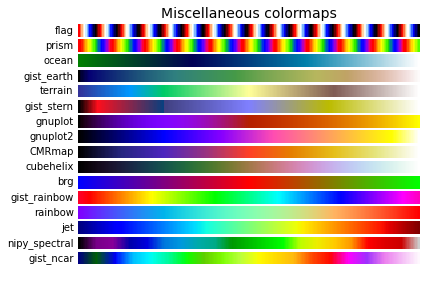

```python
nrows = max(len(cmap_list) for cmap_category, cmap_list in cmaps.items())
gradient = np.linspace(0, 1, 256)
gradient = np.vstack((gradient, gradient))


def plot_color_gradients(cmap_category, cmap_list, nrows):
    fig, axes = plt.subplots(nrows=nrows)
    fig.subplots_adjust(top=0.95, bottom=0.01, left=0.2, right=0.99)
    axes[0].set_title(cmap_category + ' colormaps', fontsize=14) #title of each category

    for ax, name in zip(axes, cmap_list):
        ax.imshow(gradient, aspect='auto', cmap=plt.get_cmap(name))
        pos = list(ax.get_position().bounds)
        x_text = pos[0] - 0.01
        y_text = pos[1] + pos[3]/2.
        fig.text(x_text, y_text, name, va='center', ha='right', fontsize=10)

    for ax in axes:
        ax.set_axis_off() #spines OFF

for cmap_category, cmap_list in cmaps.items():
    plot_color_gradients(cmap_category, cmap_list, nrows) #display all gradients in that category

plt.show()
```

# Colormap Scatterplot

To use colormaps in an actual example, we can created a scatterplot and add colormaps to increase its visual appeal.

```python
N=50
x=np.random.rand(50)
y=np.random.rand(50)
area = (30 * np.random.rand(N))**2
```

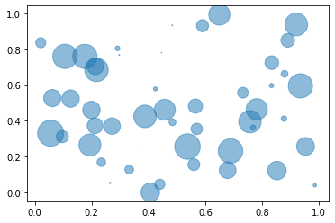

```python
N = 50
x = np.random.rand(N)
y = np.random.rand(N)
area = (30 * np.random.rand(N))**2  # 0 to 15 point radii
plt.scatter(x, y, s=area, alpha=0.5)
plt.show()
```

**The above scatterplot looks decent, but could look much cooler!**  
In the below examples, I am changing the applied colormap with the cmap argumnt and setting the color, c, to the y value. This means the color will be based off the y location of each point and will thus create a gradient effect.

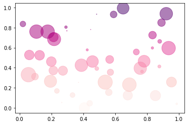

```python
plt.scatter(x, y, c=y, cmap='RdPu', s=area, alpha=0.5)
plt.show()
```

This looks much nicer than just a single color! Lets apply some more colormaps by changing the cmap value. This can be set to any of the colormaps shown in the above example.

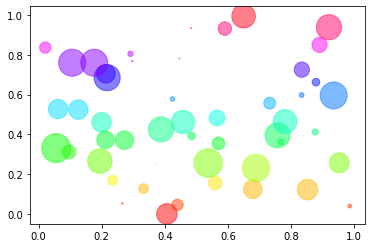

```python
plt.scatter(x, y, c=y, cmap='hsv', s=area, alpha=0.5)
plt.show()
```

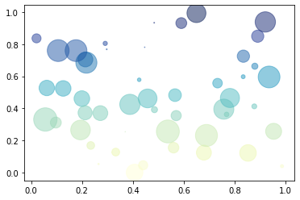

```python
plt.scatter(x, y, c=y, cmap='YlGnBu', s=area, alpha=0.5)
plt.show()
```

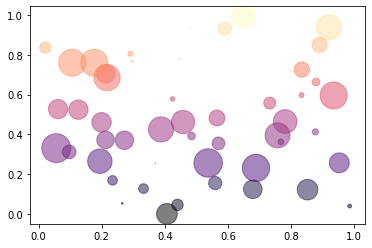

```python
plt.scatter(x, y, c=y, cmap='magma', s=area, alpha=0.5)
plt.show()
```

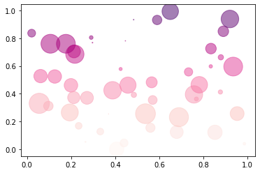

```python
plt.scatter(x, y, c=y, cmap='RdPu', s=area, alpha=0.5)
plt.show()
```